# Untitled

Hojjatollah Sadeqi

12/15/2020

# Patient Case Presentation

- A 57 years old man with typical chest pain
- 247 code (Cath-Lab)
- PCI of RCA
- Loss of Consciousness and Intubation
- Cardiac Arrest and CPR
- IABP Placement
- Infusion Levofed
- Operation Room

# Vital Sign

- BP = 80/50
- HR = 110
- O2Sat = 92%

# Lab Test

- Na = 141
- K = 2.8
- Hb = 11.9
- BS = 255
- Lactat = 5.5
- ABG
  - PH = 7.13
  - PO<sub>2</sub> = 87
  - PCO<sub>2</sub> = 54
  - HCO<sub>3</sub> = 18
  - BE = -11

# Preoperation TEE

- EF = 10-15%
- Moderate-Sever MR
- No PE

# Intra-aortic Balloon Pump

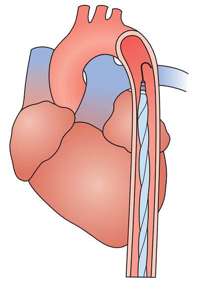

# Indications and Contraindications

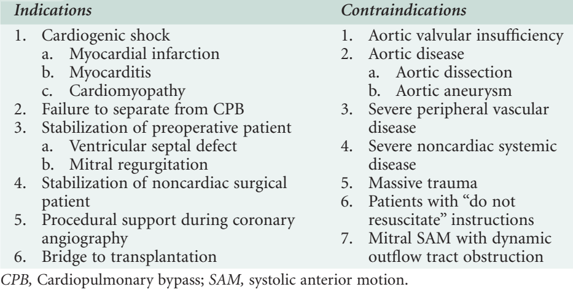

# Arterial Waveforms During IABP assist

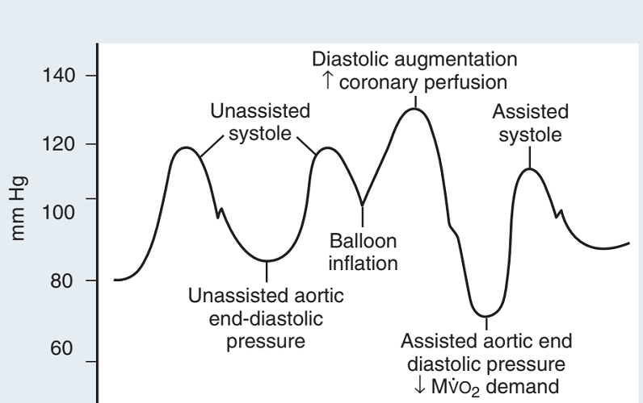

# Indications for Placement

- In the cardiac catheterization laboratory
  - High-grade lesion of proximal coronary vessels
  - MI occurs after an intervention
- LV failure despite moderate-to-high-dose inotropic support
- Evidence of ongoing regional myocardial ischemia

# Contraindications to Placement

- Aortic Insufficiency
- Sepsis
- Sever Vascular Disease

# Functional Design

- The balloon inflates during diastole
- Increasing aortic diastole pressure
- Balloon inflation improves coronary perfusion pressure
- During early systole, rapid balloon deflation reduces LV afterload

# IABP Placement

- The balloon is ideally positioned so that its tip is at the junction of the descending aorta and the aortic arch
- Radiographically the tip should lie between the anterior portion of the second intercostal space and the first lumbar vertebra
- When the IABP is placed intraoperatively, TEE can confirm proper tip location before initiation of balloon assitance

# IABP Control

- Synchronization of the IABP
  - Cardiac rhythm (EKG - Arterial Pressure waveform)
- Timing of Balloon Inflation and Deflation
  - It is important to time the onset of the pressure rise caused by balloon inflation with the dicrotic notch of the arterial waveform
- Ratio of Native Ventricle Pulsations to IABP Pulsation
- Stroke Volume of the Balloon

# Manipulation of Timing

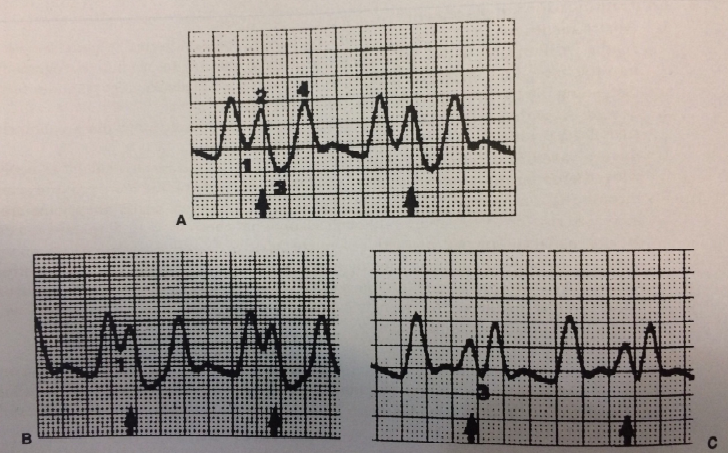

# Normal Size Balloon

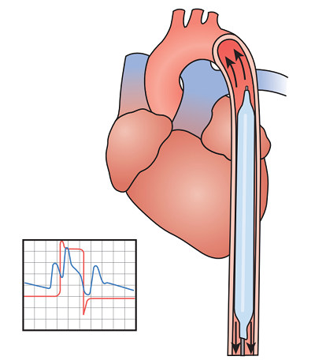

# Balloon Too Large

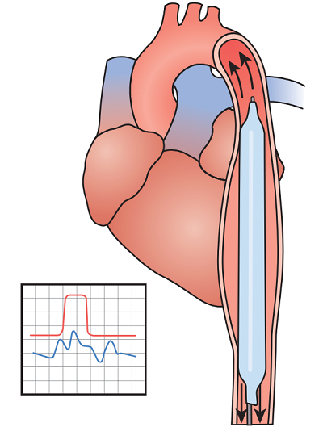

# Balloon Too Small

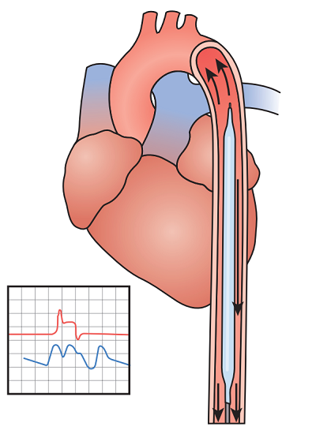

# IABP Weaning

- Weaning is done primarily by gradually decreasing the ratio of augmented to native heartbeats

# Management of Anticoagulation During IABP Assistance

- During extended IABP use, anticoagulation is generally indicated
- If heparin is used, adequate anticoagulation should be confirmed every 4 to 6 hours with ACT or PTT

# Complication

- Limb Ischemia
- Compartment Syndrome
- Mesenteric Infarction
- Aortic Perforation
- Aortic Dissection

# IABP Complications

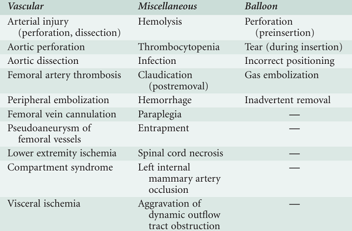

# Risk Factors for Complication

- Peripheral Vascular Disease
- Female Gender
- Tobacco Smoking
- DM

> Little old ladies and balloon pump  
> don’t mix